# Correlations

Appearing in the order they are reported, correlation analyses for:

1. Correlation between self-rating and confidence
2. Correlation for accuracy - participant/individual level

*Note - For correlation between word completion speed and predicted position please see speed_analysis file

LOAD PACKAGES

CREATE DATAFRAMES

| X | success | trial_type | trial_index | time_elapsed | internal_node_id | protocol_sum | subject_identifier | subject_sum | subject_pair | STUDY_ID | PROLIFIC_PID | SESSION_ID | practice_instructions | leaderboard_instructions | bonus | reveal_word | self_rating | confidence | view_history | rt | responses | question_order | correct | test_part | word | final_keyboard_state | num_clicks | points | cheat | … |
| --- | --- | --- | --- | --- | --- | --- | --- | --- | --- | --- | --- | --- | --- | --- | --- | --- | --- | --- | --- | --- | --- | --- | --- | --- | --- | --- | --- | --- | --- | --- |
| 1 | true | fullscreen | 0 | 3105 | 0.0-0.0 | NA | 20 | 74,68,220,21,54,66,4,168,15,232,14,144,57,69,92,193,96,130,129,130,15,226,178,79,30,82,51,173,230,175,29,213 | 10 | 669a58f4f17d67c0aba4c4d3 | 5d4c78071b920f00198e8533 | 669a5c6f777f0ecd9e7b0369 | 1 | 0 | 0 | false | 3 | 0 | NA | NA | NA | NA | NA | NA | NA | NA | NA | NA | NA | … |
| 2 | NA | instructions | 1 | 11527 | 0.0-1.0 | NA | 20 | 74,68,220,21,54,66,4,168,15,232,14,144,57,69,92,193,96,130,129,130,15,226,178,79,30,82,51,173,230,175,29,213 | 10 | 669a58f4f17d67c0aba4c4d3 | 5d4c78071b920f00198e8533 | 669a5c6f777f0ecd9e7b0369 | 1 | 0 | 0 | false | 3 | 0 | [{"page_index":0,"viewing_time":8420}] | 8420.5 | NA | NA | NA | NA | NA | NA | NA | NA | NA | … |
| 3 | NA | instructions | 2 | 25898 | 0.0-2.0-0.0 | NA | 20 | 74,68,220,21,54,66,4,168,15,232,14,144,57,69,92,193,96,130,129,130,15,226,178,79,30,82,51,173,230,175,29,213 | 10 | 669a58f4f17d67c0aba4c4d3 | 5d4c78071b920f00198e8533 | 669a5c6f777f0ecd9e7b0369 | 1 | 0 | 0 | false | 3 | 0 | [{"page_index":0,"viewing_time":14369.600000000093}] | 14369.8999999999 | NA | NA | NA | NA | NA | NA | NA | NA | NA | … |
| 4 | NA | survey-multi-choice | 3 | 36846 | 0.0-2.0-1.0 | NA | 20 | 74,68,220,21,54,66,4,168,15,232,14,144,57,69,92,193,96,130,129,130,15,226,178,79,30,82,51,173,230,175,29,213 | 10 | 669a58f4f17d67c0aba4c4d3 | 5d4c78071b920f00198e8533 | 669a5c6f777f0ecd9e7b0369 | 1 | 0 | 0 | false | 3 | 0 | NA | 10945.3999999999 | {"Q0":"... reveal the word with as few letter guesses as possible"} | [0] | true | multichoice_nonpretend | NA | NA | NA | NA | NA | … |
| 5 | NA | instructions | 4 | 39074 | 0.0-3.0 | NA | 20 | 74,68,220,21,54,66,4,168,15,232,14,144,57,69,92,193,96,130,129,130,15,226,178,79,30,82,51,173,230,175,29,213 | 10 | 669a58f4f17d67c0aba4c4d3 | 5d4c78071b920f00198e8533 | 669a5c6f777f0ecd9e7b0369 | 1 | 0 | 0 | false | 3 | 0 | [{"page_index":0,"viewing_time":2227}] | 2227.29999999981 | NA | NA | NA | NA | NA | NA | NA | NA | NA | … |
| 7 | NA | instructions | 6 | 96709 | 0.0-5.0 | NA | 20 | 74,68,220,21,54,66,4,168,15,232,14,144,57,69,92,193,96,130,129,130,15,226,178,79,30,82,51,173,230,175,29,213 | 10 | 669a58f4f17d67c0aba4c4d3 | 5d4c78071b920f00198e8533 | 669a5c6f777f0ecd9e7b0369 | 1 | 0 | 0 | false | 3 | 0 | [{"page_index":0,"viewing_time":1995.6000000000931},{"page_index":1,"viewing_time":10677}] | 12673.3999999999 | NA | NA | NA | NA | NA | NA | NA | NA | NA | … |
| 8 | NA | survey-multi-choice | 7 | 103211 | 0.0-6.0 | NA | 20 | 74,68,220,21,54,66,4,168,15,232,14,144,57,69,92,193,96,130,129,130,15,226,178,79,30,82,51,173,230,175,29,213 | 10 | 669a58f4f17d67c0aba4c4d3 | 5d4c78071b920f00198e8533 | 669a5c6f777f0ecd9e7b0369 | 1 | 0 | 0 | false | 3 | 0 | NA | 6500 | {"Q0":"...from a previous session that is part of the upcoming tournament."} | [0] | false | multichoice_leaderboard | NA | NA | NA | NA | NA | … |
| 9 | NA | instructions | 8 | 105328 | 0.0-7.0-0.0 | NA | 20 | 74,68,220,21,54,66,4,168,15,232,14,144,57,69,92,193,96,130,129,130,15,226,178,79,30,82,51,173,230,175,29,213 | 10 | 669a58f4f17d67c0aba4c4d3 | 5d4c78071b920f00198e8533 | 669a5c6f777f0ecd9e7b0369 | 1 | 0 | 0 | false | 3 | 0 | [{"page_index":0,"viewing_time":2116}] | 2116.20000000019 | NA | NA | NA | NA | NA | NA | NA | NA | NA | … |
| 10 | NA | survey-multi-choice | 9 | 111361 | 0.0-7.0-1.0 | NA | 20 | 74,68,220,21,54,66,4,168,15,232,14,144,57,69,92,193,96,130,129,130,15,226,178,79,30,82,51,173,230,175,29,213 | 10 | 669a58f4f17d67c0aba4c4d3 | 5d4c78071b920f00198e8533 | 669a5c6f777f0ecd9e7b0369 | 1 | 0 | 0 | false | 3 | 0 | NA | 6031.40000000037 | {"Q0":"...from a previous session that is part of the upcoming tournament."} | [0] | false | multichoice_leaderboard | NA | NA | NA | NA | NA | … |
| 11 | NA | instructions | 10 | 113209 | 0.0-7.1-0.1 | NA | 20 | 74,68,220,21,54,66,4,168,15,232,14,144,57,69,92,193,96,130,129,130,15,226,178,79,30,82,51,173,230,175,29,213 | 10 | 669a58f4f17d67c0aba4c4d3 | 5d4c78071b920f00198e8533 | 669a5c6f777f0ecd9e7b0369 | 1 | 0 | 0 | false | 3 | 0 | [{"page_index":0,"viewing_time":1845.2000000001863}] | 1845.60000000009 | NA | NA | NA | NA | NA | NA | NA | NA | NA | … |

[output cut: 990 more lines]

# Prepare all the dataframes

| subj_id | word | num_clicks |
| --- | --- | --- |
| 5d4c78071b920f00198e8533 | KENTUCKY | 9 |
| 5d4c78071b920f00198e8533 | SHAKIRA | 7 |
| 5d4c78071b920f00198e8533 | THIRTY FOUR | 12 |
| 5d4c78071b920f00198e8533 | NECTARINE | 10 |
| 5d4c78071b920f00198e8533 | THUMB | 10 |
| 5589565cfdf99b6bd06016dc | KENTUCKY | 9 |
| 5589565cfdf99b6bd06016dc | SHAKIRA | 7 |
| 5589565cfdf99b6bd06016dc | THIRTY FOUR | 12 |
| 5589565cfdf99b6bd06016dc | NECTARINE | 10 |
| 5589565cfdf99b6bd06016dc | THUMB | 10 |

[output cut: 990 more lines]

| subj_id | confidence |
| --- | --- |
| 5589565cfdf99b6bd06016dc | 18 |
| 5748814f7fd0ec000fb6e5bf | 28 |
| 57dd186e6598aa0001992616 | 79 |
| 588ab33542c8e900019d02ae | 80 |
| 5a6eac90d5d4cb0001d6815a | 27 |
| 5a791168f49c9a0001f31061 | 91 |
| 5bac1d9dc1155b0001175e55 | 100 |
| 5c1942e200849900010afdcd | 33 |
| 5c3820ee1ede2b0001155929 | 39 |
| 5d4c78071b920f00198e8533 | 0 |

[output cut: 190 more lines]

| subj_id | subject_pair | word | position | position_RT | true_position | reveal_word | player | distance | self_rating |
| --- | --- | --- | --- | --- | --- | --- | --- | --- | --- |
| 5d4c78071b920f00198e8533 | 10 | KENTUCKY | 15 | 11562.0999999996 | 8 | false | 5 | 7 | 3 |
| 5d4c78071b920f00198e8533 | 10 | SHAKIRA | 12 | 3140.79999999981 | 19 | false | 11 | 7 | 3 |
| 5d4c78071b920f00198e8533 | 10 | THIRTY FOUR | 30 | 1754.79999999981 | 65 | false | 81 | 35 | 3 |
| 5d4c78071b920f00198e8533 | 10 | NECTARINE | 19 | 3974.20000000019 | 72 | false | 33 | 53 | 3 |
| 5d4c78071b920f00198e8533 | 10 | THUMB | 43 | 1486.5 | 28 | false | 84 | 15 | 3 |
| 5589565cfdf99b6bd06016dc | 10 | KENTUCKY | 35 | 11564.599999994 | 8 | true | 5 | 27 | 4 |
| 5589565cfdf99b6bd06016dc | 10 | SHAKIRA | 15 | 2886.40000000596 | 19 | true | 11 | 4 | 4 |
| 5589565cfdf99b6bd06016dc | 10 | THIRTY FOUR | 81 | 4781 | 65 | true | 81 | 16 | 4 |
| 5589565cfdf99b6bd06016dc | 10 | NECTARINE | 33 | 6758.70000000298 | 72 | true | 33 | 39 | 4 |
| 5589565cfdf99b6bd06016dc | 10 | THUMB | 81 | 7892.79999999702 | 28 | true | 84 | 53 | 4 |

[output cut: 990 more lines]

| subj_id | word | num_clicks | subject_pair | position | position_RT | true_position | reveal_word | player | distance | self_rating | confidence |
| --- | --- | --- | --- | --- | --- | --- | --- | --- | --- | --- | --- |
| 5589565cfdf99b6bd06016dc | KENTUCKY | 9 | 10 | 35 | 11564.599999994 | 8 | true | 5 | 27 | 4 | 18 |
| 5589565cfdf99b6bd06016dc | NECTARINE | 10 | 10 | 33 | 6758.70000000298 | 72 | true | 33 | 39 | 4 | 18 |
| 5589565cfdf99b6bd06016dc | SHAKIRA | 7 | 10 | 15 | 2886.40000000596 | 19 | true | 11 | 4 | 4 | 18 |
| 5589565cfdf99b6bd06016dc | THIRTY FOUR | 12 | 10 | 81 | 4781 | 65 | true | 81 | 16 | 4 | 18 |
| 5589565cfdf99b6bd06016dc | THUMB | 10 | 10 | 81 | 7892.79999999702 | 28 | true | 84 | 53 | 4 | 18 |
| 5748814f7fd0ec000fb6e5bf | FIG | 3 | 56 | 2 | 3055.89999997616 | 79 | true | 59 | 77 | 5 | 28 |
| 5748814f7fd0ec000fb6e5bf | HAWAII | 5 | 56 | 4 | 7113.89999997616 | 5 | true | 13 | 1 | 5 | 28 |
| 5748814f7fd0ec000fb6e5bf | THIRTY FOUR | 16 | 56 | 35 | 3571.29999995232 | 89 | true | 91 | 54 | 5 | 28 |
| 5748814f7fd0ec000fb6e5bf | USAIN BOLT | 18 | 56 | 57 | 5571.59999990463 | 62 | true | 41 | 5 | 5 | 28 |
| 5748814f7fd0ec000fb6e5bf | WRIST | 19 | 56 | 84 | 2449 | 89 | true | 32 | 5 | 5 | 28 |

[output cut: 990 more lines]

| subj_id | word | num_clicks | subject_pair | position | position_RT | true_position | reveal_word | player | distance | self_rating | confidence |
| --- | --- | --- | --- | --- | --- | --- | --- | --- | --- | --- | --- |
| 5589565cfdf99b6bd06016dc | KENTUCKY | 9 | 10 | 35 | 11564.599999994 | 8 | revealed | 5 | 27 | 4 | 18 |
| 5589565cfdf99b6bd06016dc | NECTARINE | 10 | 10 | 33 | 6758.70000000298 | 72 | revealed | 33 | 39 | 4 | 18 |
| 5589565cfdf99b6bd06016dc | SHAKIRA | 7 | 10 | 15 | 2886.40000000596 | 19 | revealed | 11 | 4 | 4 | 18 |
| 5589565cfdf99b6bd06016dc | THIRTY FOUR | 12 | 10 | 81 | 4781 | 65 | revealed | 81 | 16 | 4 | 18 |
| 5589565cfdf99b6bd06016dc | THUMB | 10 | 10 | 81 | 7892.79999999702 | 28 | revealed | 84 | 53 | 4 | 18 |
| 5748814f7fd0ec000fb6e5bf | FIG | 3 | 56 | 2 | 3055.89999997616 | 79 | revealed | 59 | 77 | 5 | 28 |
| 5748814f7fd0ec000fb6e5bf | HAWAII | 5 | 56 | 4 | 7113.89999997616 | 5 | revealed | 13 | 1 | 5 | 28 |
| 5748814f7fd0ec000fb6e5bf | THIRTY FOUR | 16 | 56 | 35 | 3571.29999995232 | 89 | revealed | 91 | 54 | 5 | 28 |
| 5748814f7fd0ec000fb6e5bf | USAIN BOLT | 18 | 56 | 57 | 5571.59999990463 | 62 | revealed | 41 | 5 | 5 | 28 |
| 5748814f7fd0ec000fb6e5bf | WRIST | 19 | 56 | 84 | 2449 | 89 | revealed | 32 | 5 | 5 | 28 |

[output cut: 990 more lines]

| subject_pair | word | player | true_position | num_clicks | subj_id.hidden | position.hidden | position_RT.hidden | reveal_word.hidden | distance.hidden | self_rating.hidden | confidence.hidden | subj_id.revealed | position.revealed | position_RT.revealed | reveal_word.revealed | distance.revealed | self_rating.revealed | confidence.revealed |
| --- | --- | --- | --- | --- | --- | --- | --- | --- | --- | --- | --- | --- | --- | --- | --- | --- | --- | --- |
| 10 | KENTUCKY | 5 | 8 | 9 | 5d4c78071b920f00198e8533 | 15 | 11562.0999999996 | hidden | 7 | 3 | 0 | 5589565cfdf99b6bd06016dc | 35 | 11564.599999994 | revealed | 27 | 4 | 18 |
| 10 | NECTARINE | 33 | 72 | 10 | 5d4c78071b920f00198e8533 | 19 | 3974.20000000019 | hidden | 53 | 3 | 0 | 5589565cfdf99b6bd06016dc | 33 | 6758.70000000298 | revealed | 39 | 4 | 18 |
| 10 | SHAKIRA | 11 | 19 | 7 | 5d4c78071b920f00198e8533 | 12 | 3140.79999999981 | hidden | 7 | 3 | 0 | 5589565cfdf99b6bd06016dc | 15 | 2886.40000000596 | revealed | 4 | 4 | 18 |
| 10 | THIRTY FOUR | 81 | 65 | 12 | 5d4c78071b920f00198e8533 | 30 | 1754.79999999981 | hidden | 35 | 3 | 0 | 5589565cfdf99b6bd06016dc | 81 | 4781 | revealed | 16 | 4 | 18 |
| 10 | THUMB | 84 | 28 | 10 | 5d4c78071b920f00198e8533 | 43 | 1486.5 | hidden | 15 | 3 | 0 | 5589565cfdf99b6bd06016dc | 81 | 7892.79999999702 | revealed | 53 | 4 | 18 |
| 100 | FIG | 44 | 26 | 3 | 669d2e3514022f35e47da6d8 | 70 | 9901 | hidden | 44 | 3 | 100 | 666e20c484d272cadcc536c9 | 100 | 2931.29999999702 | revealed | 74 | 3 | 69 |
| 100 | HAWAII | 85 | 3 | 5 | 669d2e3514022f35e47da6d8 | 20 | 7813 | hidden | 17 | 3 | 100 | 666e20c484d272cadcc536c9 | 32 | 2177.29999999702 | revealed | 29 | 3 | 69 |
| 100 | SHAKIRA | 33 | 72 | 12 | 669d2e3514022f35e47da6d8 | 35 | 3554 | hidden | 37 | 3 | 100 | 666e20c484d272cadcc536c9 | 58 | 3135 | revealed | 14 | 3 | 69 |
| 100 | THIRTY FOUR | 90 | 13 | 9 | 669d2e3514022f35e47da6d8 | 4 | 6706 | hidden | 9 | 3 | 100 | 666e20c484d272cadcc536c9 | 45 | 1845.10000000894 | revealed | 32 | 3 | 69 |
| 100 | THUMB | 66 | 92 | 18 | 669d2e3514022f35e47da6d8 | 1 | 2951 | hidden | 91 | 3 | 100 | 666e20c484d272cadcc536c9 | 22 | 5324.39999999106 | revealed | 70 | 3 | 69 |

[output cut: 490 more lines]

| subj_id | word | num_clicks | position | reveal_word |
| --- | --- | --- | --- | --- |
| 5589565cfdf99b6bd06016dc | KENTUCKY | 9 | 35 | revealed |
| 5589565cfdf99b6bd06016dc | NECTARINE | 10 | 33 | revealed |
| 5589565cfdf99b6bd06016dc | SHAKIRA | 7 | 15 | revealed |
| 5589565cfdf99b6bd06016dc | THIRTY FOUR | 12 | 81 | revealed |
| 5589565cfdf99b6bd06016dc | THUMB | 10 | 81 | revealed |
| 5748814f7fd0ec000fb6e5bf | FIG | 3 | 2 | revealed |
| 5748814f7fd0ec000fb6e5bf | HAWAII | 5 | 4 | revealed |
| 5748814f7fd0ec000fb6e5bf | THIRTY FOUR | 16 | 35 | revealed |
| 5748814f7fd0ec000fb6e5bf | USAIN BOLT | 18 | 57 | revealed |
| 5748814f7fd0ec000fb6e5bf | WRIST | 19 | 84 | revealed |

[output cut: 990 more lines]

Make a new column which counts the number of letters in each word and calls this the correct number of guesses

| subj_id | word | num_clicks | position | reveal_word | correct_number_guess |
| --- | --- | --- | --- | --- | --- |
| 5589565cfdf99b6bd06016dc | KENTUCKY | 9 | 35 | revealed | 8 |
| 5589565cfdf99b6bd06016dc | NECTARINE | 10 | 33 | revealed | 9 |
| 5589565cfdf99b6bd06016dc | SHAKIRA | 7 | 15 | revealed | 7 |
| 5589565cfdf99b6bd06016dc | THIRTY FOUR | 12 | 81 | revealed | 11 |
| 5589565cfdf99b6bd06016dc | THUMB | 10 | 81 | revealed | 5 |
| 5748814f7fd0ec000fb6e5bf | FIG | 3 | 2 | revealed | 3 |
| 5748814f7fd0ec000fb6e5bf | HAWAII | 5 | 4 | revealed | 6 |
| 5748814f7fd0ec000fb6e5bf | THIRTY FOUR | 16 | 35 | revealed | 11 |
| 5748814f7fd0ec000fb6e5bf | USAIN BOLT | 18 | 57 | revealed | 10 |
| 5748814f7fd0ec000fb6e5bf | WRIST | 19 | 84 | revealed | 5 |

[output cut: 990 more lines]

Create a new column to count the misses

| subj_id | word | num_clicks | position | reveal_word | correct_number_guess | misses |
| --- | --- | --- | --- | --- | --- | --- |
| 5589565cfdf99b6bd06016dc | KENTUCKY | 9 | 35 | revealed | 8 | 1 |
| 5589565cfdf99b6bd06016dc | NECTARINE | 10 | 33 | revealed | 9 | 1 |
| 5589565cfdf99b6bd06016dc | SHAKIRA | 7 | 15 | revealed | 7 | 0 |
| 5589565cfdf99b6bd06016dc | THIRTY FOUR | 12 | 81 | revealed | 11 | 1 |
| 5589565cfdf99b6bd06016dc | THUMB | 10 | 81 | revealed | 5 | 5 |
| 5748814f7fd0ec000fb6e5bf | FIG | 3 | 2 | revealed | 3 | 0 |
| 5748814f7fd0ec000fb6e5bf | HAWAII | 5 | 4 | revealed | 6 | 1 |
| 5748814f7fd0ec000fb6e5bf | THIRTY FOUR | 16 | 35 | revealed | 11 | 5 |
| 5748814f7fd0ec000fb6e5bf | USAIN BOLT | 18 | 57 | revealed | 10 | 8 |
| 5748814f7fd0ec000fb6e5bf | WRIST | 19 | 84 | revealed | 5 | 14 |

[output cut: 990 more lines]

| word | mean_misses |
| --- | --- |
| FIG | 2.750000 |
| HAWAII | 2.296296 |
| KENTUCKY | 3.152174 |
| NECTARINE | 1.961538 |
| SHAKIRA | 6.235294 |
| THIRTY FOUR | 2.080000 |
| THUMB | 5.208333 |
| USAIN BOLT | 2.591837 |
| WRIST | 4.038462 |

| subj_id | word | num_clicks | position | reveal_word | correct_number_guess | misses | mean_misses |
| --- | --- | --- | --- | --- | --- | --- | --- |
| 5589565cfdf99b6bd06016dc | KENTUCKY | 9 | 35 | revealed | 8 | 1 | 3.152174 |
| 5589565cfdf99b6bd06016dc | NECTARINE | 10 | 33 | revealed | 9 | 1 | 1.961538 |
| 5589565cfdf99b6bd06016dc | SHAKIRA | 7 | 15 | revealed | 7 | 0 | 6.235294 |
| 5589565cfdf99b6bd06016dc | THIRTY FOUR | 12 | 81 | revealed | 11 | 1 | 2.080000 |
| 5589565cfdf99b6bd06016dc | THUMB | 10 | 81 | revealed | 5 | 5 | 5.208333 |
| 5748814f7fd0ec000fb6e5bf | FIG | 3 | 2 | revealed | 3 | 0 | 2.750000 |
| 5748814f7fd0ec000fb6e5bf | HAWAII | 5 | 4 | revealed | 6 | 1 | 2.296296 |
| 5748814f7fd0ec000fb6e5bf | THIRTY FOUR | 16 | 35 | revealed | 11 | 5 | 2.080000 |
| 5748814f7fd0ec000fb6e5bf | USAIN BOLT | 18 | 57 | revealed | 10 | 8 | 2.591837 |
| 5748814f7fd0ec000fb6e5bf | WRIST | 19 | 84 | revealed | 5 | 14 | 4.038462 |

[output cut: 990 more lines]

Now work out player comeptence per game watched, which is miss per game - mean miss per word

| subj_id | word | num_clicks | position | reveal_word | correct_number_guess | misses | mean_misses | player_competence |
| --- | --- | --- | --- | --- | --- | --- | --- | --- |
| 5589565cfdf99b6bd06016dc | KENTUCKY | 9 | 35 | revealed | 8 | 1 | 3.152174 | -2.15217391 |
| 5589565cfdf99b6bd06016dc | NECTARINE | 10 | 33 | revealed | 9 | 1 | 1.961538 | -0.96153846 |
| 5589565cfdf99b6bd06016dc | SHAKIRA | 7 | 15 | revealed | 7 | 0 | 6.235294 | -6.23529412 |
| 5589565cfdf99b6bd06016dc | THIRTY FOUR | 12 | 81 | revealed | 11 | 1 | 2.080000 | -1.08000000 |
| 5589565cfdf99b6bd06016dc | THUMB | 10 | 81 | revealed | 5 | 5 | 5.208333 | -0.20833333 |
| 5748814f7fd0ec000fb6e5bf | FIG | 3 | 2 | revealed | 3 | 0 | 2.750000 | -2.75000000 |
| 5748814f7fd0ec000fb6e5bf | HAWAII | 5 | 4 | revealed | 6 | 1 | 2.296296 | -1.29629630 |
| 5748814f7fd0ec000fb6e5bf | THIRTY FOUR | 16 | 35 | revealed | 11 | 5 | 2.080000 | 2.92000000 |
| 5748814f7fd0ec000fb6e5bf | USAIN BOLT | 18 | 57 | revealed | 10 | 8 | 2.591837 | 5.40816327 |
| 5748814f7fd0ec000fb6e5bf | WRIST | 19 | 84 | revealed | 5 | 14 | 4.038462 | 9.96153846 |

[output cut: 990 more lines]

1. CORRELATION BETWEEN SELF-RATING AND CONFIDENCE# ##################################################

| subj_id | self_rating | confidence | reveal_word |
| --- | --- | --- | --- |
| 5589565cfdf99b6bd06016dc | 4 | 18 | revealed |
| 5589565cfdf99b6bd06016dc | 4 | 18 | revealed |
| 5589565cfdf99b6bd06016dc | 4 | 18 | revealed |
| 5589565cfdf99b6bd06016dc | 4 | 18 | revealed |
| 5589565cfdf99b6bd06016dc | 4 | 18 | revealed |
| 5748814f7fd0ec000fb6e5bf | 5 | 28 | revealed |
| 5748814f7fd0ec000fb6e5bf | 5 | 28 | revealed |
| 5748814f7fd0ec000fb6e5bf | 5 | 28 | revealed |
| 5748814f7fd0ec000fb6e5bf | 5 | 28 | revealed |
| 5748814f7fd0ec000fb6e5bf | 5 | 28 | revealed |

[output cut: 990 more lines]

| subj_id | self_rating | confidence | reveal_word |
| --- | --- | --- | --- |
| 5589565cfdf99b6bd06016dc | 4 | 18 | revealed |
| 5748814f7fd0ec000fb6e5bf | 5 | 28 | revealed |
| 57dd186e6598aa0001992616 | 2 | 79 | hidden |
| 588ab33542c8e900019d02ae | 4 | 80 | revealed |
| 5a6eac90d5d4cb0001d6815a | 4 | 27 | hidden |
| 5a791168f49c9a0001f31061 | 6 | 91 | hidden |
| 5bac1d9dc1155b0001175e55 | 2 | 100 | revealed |
| 5c1942e200849900010afdcd | 3 | 33 | revealed |
| 5c3820ee1ede2b0001155929 | 3 | 39 | hidden |
| 5d4c78071b920f00198e8533 | 3 | 0 | hidden |

[output cut: 190 more lines]

| subj_id | self_rating | confidence | reveal_word |
| --- | --- | --- | --- |
| 5589565cfdf99b6bd06016dc | 4 | 18 | revealed |
| 5748814f7fd0ec000fb6e5bf | 5 | 28 | revealed |
| 588ab33542c8e900019d02ae | 4 | 80 | revealed |
| 5bac1d9dc1155b0001175e55 | 2 | 100 | revealed |
| 5c1942e200849900010afdcd | 3 | 33 | revealed |
| 5d612ae16512d700159face7 | 3 | 76 | revealed |
| 5d6513f46f5284000118ef1d | 5 | 22 | revealed |
| 5d6ac7e17658a1001a8c63b2 | 2 | 100 | revealed |
| 5d74001d391b6600175f433b | 2 | 27 | revealed |
| 5d7fec0793bb8600164dd05f | 3 | 65 | revealed |

[output cut: 90 more lines]

| subj_id | self_rating | confidence | reveal_word |
| --- | --- | --- | --- |
| 57dd186e6598aa0001992616 | 2 | 79 | hidden |
| 5a6eac90d5d4cb0001d6815a | 4 | 27 | hidden |
| 5a791168f49c9a0001f31061 | 6 | 91 | hidden |
| 5c3820ee1ede2b0001155929 | 3 | 39 | hidden |
| 5d4c78071b920f00198e8533 | 3 | 0 | hidden |
| 5e00f9a211999fcea4169800 | 4 | 32 | hidden |
| 5e1fd25f1160072f44b93722 | 5 | 16 | hidden |
| 5ee2a663afc30b40867d4535 | 6 | 76 | hidden |
| 5ef11899b242da1e73a5b1e4 | 6 | 100 | hidden |
| 5f04b7a99b50ac10df3a9eac | 1 | 25 | hidden |

[output cut: 90 more lines]

Fishers r-to-z transformation to compare the two correlations:

2. CORRELATION FOR ACCURACY - PARTICIPANT/INDVIDUAL LEVEL # ###########################################################

Do a correlation for each ppt between their predicted position and true position

| subj_id | correlation |
| --- | --- |
| 5589565cfdf99b6bd06016dc | 0.309480562 |
| 5748814f7fd0ec000fb6e5bf | 0.507875497 |
| 57dd186e6598aa0001992616 | 0.662325524 |
| 588ab33542c8e900019d02ae | 0.959856167 |
| 5a6eac90d5d4cb0001d6815a | -0.464497035 |
| 5a791168f49c9a0001f31061 | 0.261441144 |
| 5bac1d9dc1155b0001175e55 | -0.412292205 |
| 5c1942e200849900010afdcd | -0.490684274 |
| 5c3820ee1ede2b0001155929 | -0.126780902 |
| 5d4c78071b920f00198e8533 | 0.207345297 |

[output cut: 190 more lines]

Now by condition

Make a dataframe for revealed and for hidden

| subj_id | word | num_clicks | subject_pair | position | position_RT | true_position | reveal_word | player | distance | self_rating | confidence |
| --- | --- | --- | --- | --- | --- | --- | --- | --- | --- | --- | --- |
| 5589565cfdf99b6bd06016dc | KENTUCKY | 9 | 10 | 35 | 11564.599999994 | 8 | revealed | 5 | 27 | 4 | 18 |
| 5589565cfdf99b6bd06016dc | NECTARINE | 10 | 10 | 33 | 6758.70000000298 | 72 | revealed | 33 | 39 | 4 | 18 |
| 5589565cfdf99b6bd06016dc | SHAKIRA | 7 | 10 | 15 | 2886.40000000596 | 19 | revealed | 11 | 4 | 4 | 18 |
| 5589565cfdf99b6bd06016dc | THIRTY FOUR | 12 | 10 | 81 | 4781 | 65 | revealed | 81 | 16 | 4 | 18 |
| 5589565cfdf99b6bd06016dc | THUMB | 10 | 10 | 81 | 7892.79999999702 | 28 | revealed | 84 | 53 | 4 | 18 |
| 5748814f7fd0ec000fb6e5bf | FIG | 3 | 56 | 2 | 3055.89999997616 | 79 | revealed | 59 | 77 | 5 | 28 |
| 5748814f7fd0ec000fb6e5bf | HAWAII | 5 | 56 | 4 | 7113.89999997616 | 5 | revealed | 13 | 1 | 5 | 28 |
| 5748814f7fd0ec000fb6e5bf | THIRTY FOUR | 16 | 56 | 35 | 3571.29999995232 | 89 | revealed | 91 | 54 | 5 | 28 |
| 5748814f7fd0ec000fb6e5bf | USAIN BOLT | 18 | 56 | 57 | 5571.59999990463 | 62 | revealed | 41 | 5 | 5 | 28 |
| 5748814f7fd0ec000fb6e5bf | WRIST | 19 | 56 | 84 | 2449 | 89 | revealed | 32 | 5 | 5 | 28 |

[output cut: 490 more lines]

| subj_id | word | num_clicks | subject_pair | position | position_RT | true_position | reveal_word | player | distance | self_rating | confidence |
| --- | --- | --- | --- | --- | --- | --- | --- | --- | --- | --- | --- |
| 57dd186e6598aa0001992616 | FIG | 13 | 108 | 82 | 2238.80000001192 | 79 | hidden | 28 | 3 | 2 | 79 |
| 57dd186e6598aa0001992616 | KENTUCKY | 10 | 108 | 90 | 1817.10000002384 | 29 | hidden | 92 | 61 | 2 | 79 |
| 57dd186e6598aa0001992616 | SHAKIRA | 9 | 108 | 27 | 1499.09999996424 | 10 | hidden | 2 | 17 | 2 | 79 |
| 57dd186e6598aa0001992616 | THIRTY FOUR | 12 | 108 | 92 | 1733.19999998808 | 81 | hidden | 6 | 11 | 2 | 79 |
| 57dd186e6598aa0001992616 | THUMB | 8 | 108 | 78 | 1753 | 33 | hidden | 83 | 45 | 2 | 79 |
| 5a6eac90d5d4cb0001d6815a | HAWAII | 6 | 255 | 50 | 2697.39999999991 | 58 | hidden | 46 | 8 | 4 | 27 |
| 5a6eac90d5d4cb0001d6815a | NECTARINE | 9 | 255 | 55 | 2707.29999999981 | 32 | hidden | 84 | 23 | 4 | 27 |
| 5a6eac90d5d4cb0001d6815a | THIRTY FOUR | 10 | 255 | 25 | 9163.30000000028 | 49 | hidden | 71 | 24 | 4 | 27 |
| 5a6eac90d5d4cb0001d6815a | USAIN BOLT | 11 | 255 | 30 | 5837.10000000009 | 76 | hidden | 60 | 46 | 4 | 27 |
| 5a6eac90d5d4cb0001d6815a | WRIST | 8 | 255 | 35 | 5251.39999999991 | 44 | hidden | 35 | 9 | 4 | 27 |

[output cut: 490 more lines]

| subj_id | correlation |
| --- | --- |
| 5589565cfdf99b6bd06016dc | 0.309480562 |
| 5748814f7fd0ec000fb6e5bf | 0.507875497 |
| 588ab33542c8e900019d02ae | 0.959856167 |
| 5bac1d9dc1155b0001175e55 | -0.412292205 |
| 5c1942e200849900010afdcd | -0.490684274 |
| 5d612ae16512d700159face7 | 0.381428083 |
| 5d6513f46f5284000118ef1d | 0.488110735 |
| 5d6ac7e17658a1001a8c63b2 | 0.290121679 |
| 5d74001d391b6600175f433b | 0.555675509 |
| 5d7fec0793bb8600164dd05f | 0.946934959 |

[output cut: 90 more lines]

| subj_id | correlation |
| --- | --- |
| 57dd186e6598aa0001992616 | 0.66232552 |
| 5a6eac90d5d4cb0001d6815a | -0.46449704 |
| 5a791168f49c9a0001f31061 | 0.26144114 |
| 5c3820ee1ede2b0001155929 | -0.12678090 |
| 5d4c78071b920f00198e8533 | 0.20734530 |
| 5e00f9a211999fcea4169800 | -0.36906036 |
| 5e1fd25f1160072f44b93722 | -0.70755731 |
| 5ee2a663afc30b40867d4535 | 0.84998071 |
| 5ef11899b242da1e73a5b1e4 | -0.17952202 |
| 5f04b7a99b50ac10df3a9eac | 0.32707664 |

[output cut: 90 more lines]

T-test between both

3. CORRELATION BETWEEN MEAN MISSES PER PARTICIPANT AND MEAN PREDICTED POSITION RANKING BY PARTICIPANT# ######################################################################################################

| subj_id | correlation |
| --- | --- |
| 5589565cfdf99b6bd06016dc | 0.68721104 |
| 5748814f7fd0ec000fb6e5bf | 0.99259551 |
| 57dd186e6598aa0001992616 | 0.13208203 |
| 588ab33542c8e900019d02ae | 0.65767610 |
| 5a6eac90d5d4cb0001d6815a | -0.55202026 |
| 5a791168f49c9a0001f31061 | 0.96844401 |
| 5bac1d9dc1155b0001175e55 | 0.85960735 |
| 5c1942e200849900010afdcd | 0.39319767 |
| 5c3820ee1ede2b0001155929 | 0.46916650 |
| 5d4c78071b920f00198e8533 | 0.89356659 |

[output cut: 190 more lines]

Now do it by condition

Make a dataframe for revealed and for hidden

| subj_id | word | num_clicks | position | reveal_word | correct_number_guess | misses | mean_misses | player_competence |
| --- | --- | --- | --- | --- | --- | --- | --- | --- |
| 5589565cfdf99b6bd06016dc | KENTUCKY | 9 | 35 | revealed | 8 | 1 | 3.152174 | -2.15217391 |
| 5589565cfdf99b6bd06016dc | NECTARINE | 10 | 33 | revealed | 9 | 1 | 1.961538 | -0.96153846 |
| 5589565cfdf99b6bd06016dc | SHAKIRA | 7 | 15 | revealed | 7 | 0 | 6.235294 | -6.23529412 |
| 5589565cfdf99b6bd06016dc | THIRTY FOUR | 12 | 81 | revealed | 11 | 1 | 2.080000 | -1.08000000 |
| 5589565cfdf99b6bd06016dc | THUMB | 10 | 81 | revealed | 5 | 5 | 5.208333 | -0.20833333 |
| 5748814f7fd0ec000fb6e5bf | FIG | 3 | 2 | revealed | 3 | 0 | 2.750000 | -2.75000000 |
| 5748814f7fd0ec000fb6e5bf | HAWAII | 5 | 4 | revealed | 6 | 1 | 2.296296 | -1.29629630 |
| 5748814f7fd0ec000fb6e5bf | THIRTY FOUR | 16 | 35 | revealed | 11 | 5 | 2.080000 | 2.92000000 |
| 5748814f7fd0ec000fb6e5bf | USAIN BOLT | 18 | 57 | revealed | 10 | 8 | 2.591837 | 5.40816327 |
| 5748814f7fd0ec000fb6e5bf | WRIST | 19 | 84 | revealed | 5 | 14 | 4.038462 | 9.96153846 |

[output cut: 490 more lines]

| subj_id | word | num_clicks | position | reveal_word | correct_number_guess | misses | mean_misses | player_competence |
| --- | --- | --- | --- | --- | --- | --- | --- | --- |
| 57dd186e6598aa0001992616 | FIG | 13 | 82 | hidden | 3 | 10 | 2.750000 | 7.25000000 |
| 57dd186e6598aa0001992616 | KENTUCKY | 10 | 90 | hidden | 8 | 2 | 3.152174 | -1.15217391 |
| 57dd186e6598aa0001992616 | SHAKIRA | 9 | 27 | hidden | 7 | 2 | 6.235294 | -4.23529412 |
| 57dd186e6598aa0001992616 | THIRTY FOUR | 12 | 92 | hidden | 11 | 1 | 2.080000 | -1.08000000 |
| 57dd186e6598aa0001992616 | THUMB | 8 | 78 | hidden | 5 | 3 | 5.208333 | -2.20833333 |
| 5a6eac90d5d4cb0001d6815a | HAWAII | 6 | 50 | hidden | 6 | 0 | 2.296296 | -2.29629630 |
| 5a6eac90d5d4cb0001d6815a | NECTARINE | 9 | 55 | hidden | 9 | 0 | 1.961538 | -1.96153846 |
| 5a6eac90d5d4cb0001d6815a | THIRTY FOUR | 10 | 25 | hidden | 11 | 1 | 2.080000 | -1.08000000 |
| 5a6eac90d5d4cb0001d6815a | USAIN BOLT | 11 | 30 | hidden | 10 | 1 | 2.591837 | -1.59183673 |
| 5a6eac90d5d4cb0001d6815a | WRIST | 8 | 35 | hidden | 5 | 3 | 4.038462 | -1.03846154 |

[output cut: 490 more lines]

| subj_id | correlation_revealed |
| --- | --- |
| 5589565cfdf99b6bd06016dc | 0.68721104 |
| 5748814f7fd0ec000fb6e5bf | 0.99259551 |
| 588ab33542c8e900019d02ae | 0.65767610 |
| 5bac1d9dc1155b0001175e55 | 0.85960735 |
| 5c1942e200849900010afdcd | 0.39319767 |
| 5d612ae16512d700159face7 | 0.97725707 |
| 5d6513f46f5284000118ef1d | 0.73079476 |
| 5d6ac7e17658a1001a8c63b2 | 0.32199580 |
| 5d74001d391b6600175f433b | 0.93841645 |
| 5d7fec0793bb8600164dd05f | 0.65489758 |

[output cut: 90 more lines]

| subj_id | correlation_hidden |
| --- | --- |
| 57dd186e6598aa0001992616 | 0.13208203 |
| 5a6eac90d5d4cb0001d6815a | -0.55202026 |
| 5a791168f49c9a0001f31061 | 0.96844401 |
| 5c3820ee1ede2b0001155929 | 0.46916650 |
| 5d4c78071b920f00198e8533 | 0.89356659 |
| 5e00f9a211999fcea4169800 | -0.11024745 |
| 5e1fd25f1160072f44b93722 | 0.10990737 |
| 5ee2a663afc30b40867d4535 | 0.41076390 |
| 5ef11899b242da1e73a5b1e4 | 0.71501577 |
| 5f04b7a99b50ac10df3a9eac | -0.60923365 |

[output cut: 90 more lines]

Combine correlation datasets

4. CORRELATION BETWEEN MEAN MISSES PER WORD AND MEAN RANKING PER WORD# ######################################################################

| subject_pair | word | player | num_clicks | position.hidden | position.revealed |
| --- | --- | --- | --- | --- | --- |
| 10 | KENTUCKY | 5 | 9 | 15 | 35 |
| 10 | NECTARINE | 33 | 10 | 19 | 33 |
| 10 | SHAKIRA | 11 | 7 | 12 | 15 |
| 10 | THIRTY FOUR | 81 | 12 | 30 | 81 |
| 10 | THUMB | 84 | 10 | 43 | 81 |
| 100 | FIG | 44 | 3 | 70 | 100 |
| 100 | HAWAII | 85 | 5 | 20 | 32 |
| 100 | SHAKIRA | 33 | 12 | 35 | 58 |
| 100 | THIRTY FOUR | 90 | 9 | 4 | 45 |
| 100 | THUMB | 66 | 18 | 1 | 22 |

[output cut: 490 more lines]

| subject_pair | word | player | num_clicks | position.hidden | position.revealed | correct_number_guess |
| --- | --- | --- | --- | --- | --- | --- |
| 10 | KENTUCKY | 5 | 9 | 15 | 35 | 8 |
| 10 | NECTARINE | 33 | 10 | 19 | 33 | 9 |
| 10 | SHAKIRA | 11 | 7 | 12 | 15 | 7 |
| 10 | THIRTY FOUR | 81 | 12 | 30 | 81 | 11 |
| 10 | THUMB | 84 | 10 | 43 | 81 | 5 |
| 100 | FIG | 44 | 3 | 70 | 100 | 3 |
| 100 | HAWAII | 85 | 5 | 20 | 32 | 6 |
| 100 | SHAKIRA | 33 | 12 | 35 | 58 | 7 |
| 100 | THIRTY FOUR | 90 | 9 | 4 | 45 | 11 |
| 100 | THUMB | 66 | 18 | 1 | 22 | 5 |

[output cut: 490 more lines]

Create a new column to count the misses

| subject_pair | word | player | num_clicks | position.hidden | position.revealed | correct_number_guess | misses |
| --- | --- | --- | --- | --- | --- | --- | --- |
| 10 | KENTUCKY | 5 | 9 | 15 | 35 | 8 | 1 |
| 10 | NECTARINE | 33 | 10 | 19 | 33 | 9 | 1 |
| 10 | SHAKIRA | 11 | 7 | 12 | 15 | 7 | 0 |
| 10 | THIRTY FOUR | 81 | 12 | 30 | 81 | 11 | 1 |
| 10 | THUMB | 84 | 10 | 43 | 81 | 5 | 5 |
| 100 | FIG | 44 | 3 | 70 | 100 | 3 | 0 |
| 100 | HAWAII | 85 | 5 | 20 | 32 | 6 | 1 |
| 100 | SHAKIRA | 33 | 12 | 35 | 58 | 7 | 5 |
| 100 | THIRTY FOUR | 90 | 9 | 4 | 45 | 11 | 2 |
| 100 | THUMB | 66 | 18 | 1 | 22 | 5 | 13 |

[output cut: 490 more lines]

| word | mean_misses |
| --- | --- |
| FIG | 2.750000 |
| HAWAII | 2.296296 |
| KENTUCKY | 3.152174 |
| NECTARINE | 1.961538 |
| SHAKIRA | 6.235294 |
| THIRTY FOUR | 2.080000 |
| THUMB | 5.208333 |
| USAIN BOLT | 2.591837 |
| WRIST | 4.038462 |

| word | position.hidden | position.revealed |
| --- | --- | --- |
| FIG | 32.93750 | 36.47917 |
| HAWAII | 31.66667 | 33.61111 |
| KENTUCKY | 39.04348 | 34.93478 |
| NECTARINE | 34.75000 | 31.13462 |
| SHAKIRA | 47.39216 | 49.31373 |
| THIRTY FOUR | 23.17000 | 20.29000 |
| THUMB | 42.16667 | 45.35417 |
| USAIN BOLT | 31.24490 | 30.67347 |
| WRIST | 39.11538 | 40.30769 |

Merge

| word | position.hidden | position.revealed | mean_misses |
| --- | --- | --- | --- |
| FIG | 32.93750 | 36.47917 | 2.750000 |
| HAWAII | 31.66667 | 33.61111 | 2.296296 |
| KENTUCKY | 39.04348 | 34.93478 | 3.152174 |
| NECTARINE | 34.75000 | 31.13462 | 1.961538 |
| SHAKIRA | 47.39216 | 49.31373 | 6.235294 |
| THIRTY FOUR | 23.17000 | 20.29000 | 2.080000 |
| THUMB | 42.16667 | 45.35417 | 5.208333 |
| USAIN BOLT | 31.24490 | 30.67347 | 2.591837 |
| WRIST | 39.11538 | 40.30769 | 4.038462 |

| word | position.hidden | position.revealed | mean_misses | composite_position |
| --- | --- | --- | --- | --- |
| FIG | 32.93750 | 36.47917 | 2.750000 | 34.70833 |
| HAWAII | 31.66667 | 33.61111 | 2.296296 | 32.63889 |
| KENTUCKY | 39.04348 | 34.93478 | 3.152174 | 36.98913 |
| NECTARINE | 34.75000 | 31.13462 | 1.961538 | 32.94231 |
| SHAKIRA | 47.39216 | 49.31373 | 6.235294 | 48.35294 |
| THIRTY FOUR | 23.17000 | 20.29000 | 2.080000 | 21.73000 |
| THUMB | 42.16667 | 45.35417 | 5.208333 | 43.76042 |
| USAIN BOLT | 31.24490 | 30.67347 | 2.591837 | 30.95918 |
| WRIST | 39.11538 | 40.30769 | 4.038462 | 39.71154 |

By condition

Correlation for hidden

Plot

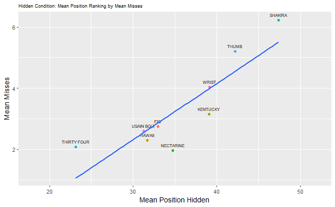

Correlation for revealed

Plot

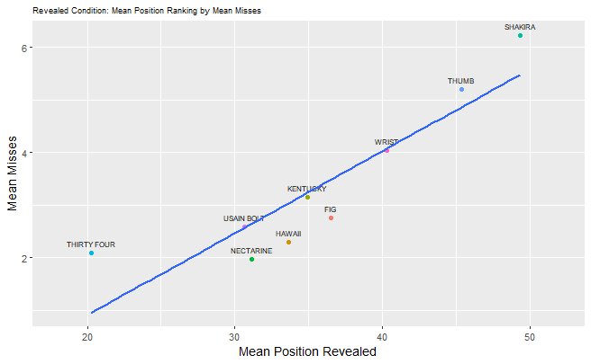

Now join the plots together

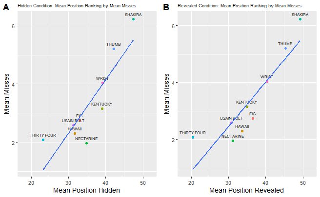

5. CORRELATION BETWEEN MEAN WORD DIFFICULTY PER PARTICIPANT AND MEAN PREDICTED POSITION RANKING BY PARTICIPANT# ###############################################################################################################

Now to do the correlation on a population level

| subj_id | correlation |
| --- | --- |
| 5589565cfdf99b6bd06016dc | -0.234610602 |
| 5748814f7fd0ec000fb6e5bf | 0.686626552 |
| 57dd186e6598aa0001992616 | -0.841596635 |
| 588ab33542c8e900019d02ae | 0.641920050 |
| 5a6eac90d5d4cb0001d6815a | -0.274132660 |
| 5a791168f49c9a0001f31061 | 0.631050116 |
| 5bac1d9dc1155b0001175e55 | -0.325774569 |
| 5c1942e200849900010afdcd | 0.841924234 |
| 5c3820ee1ede2b0001155929 | 0.669513849 |
| 5d4c78071b920f00198e8533 | 0.022244344 |

[output cut: 190 more lines]

Now do it by condition

Make a dataframe for revealed and for hidden

| subj_id | word | num_clicks | position | reveal_word | correct_number_guess | misses | mean_misses | player_competence |
| --- | --- | --- | --- | --- | --- | --- | --- | --- |
| 5589565cfdf99b6bd06016dc | KENTUCKY | 9 | 35 | revealed | 8 | 1 | 3.152174 | -2.15217391 |
| 5589565cfdf99b6bd06016dc | NECTARINE | 10 | 33 | revealed | 9 | 1 | 1.961538 | -0.96153846 |
| 5589565cfdf99b6bd06016dc | SHAKIRA | 7 | 15 | revealed | 7 | 0 | 6.235294 | -6.23529412 |
| 5589565cfdf99b6bd06016dc | THIRTY FOUR | 12 | 81 | revealed | 11 | 1 | 2.080000 | -1.08000000 |
| 5589565cfdf99b6bd06016dc | THUMB | 10 | 81 | revealed | 5 | 5 | 5.208333 | -0.20833333 |
| 5748814f7fd0ec000fb6e5bf | FIG | 3 | 2 | revealed | 3 | 0 | 2.750000 | -2.75000000 |
| 5748814f7fd0ec000fb6e5bf | HAWAII | 5 | 4 | revealed | 6 | 1 | 2.296296 | -1.29629630 |
| 5748814f7fd0ec000fb6e5bf | THIRTY FOUR | 16 | 35 | revealed | 11 | 5 | 2.080000 | 2.92000000 |
| 5748814f7fd0ec000fb6e5bf | USAIN BOLT | 18 | 57 | revealed | 10 | 8 | 2.591837 | 5.40816327 |
| 5748814f7fd0ec000fb6e5bf | WRIST | 19 | 84 | revealed | 5 | 14 | 4.038462 | 9.96153846 |

[output cut: 490 more lines]

| subj_id | word | num_clicks | position | reveal_word | correct_number_guess | misses | mean_misses | player_competence |
| --- | --- | --- | --- | --- | --- | --- | --- | --- |
| 57dd186e6598aa0001992616 | FIG | 13 | 82 | hidden | 3 | 10 | 2.750000 | 7.25000000 |
| 57dd186e6598aa0001992616 | KENTUCKY | 10 | 90 | hidden | 8 | 2 | 3.152174 | -1.15217391 |
| 57dd186e6598aa0001992616 | SHAKIRA | 9 | 27 | hidden | 7 | 2 | 6.235294 | -4.23529412 |
| 57dd186e6598aa0001992616 | THIRTY FOUR | 12 | 92 | hidden | 11 | 1 | 2.080000 | -1.08000000 |
| 57dd186e6598aa0001992616 | THUMB | 8 | 78 | hidden | 5 | 3 | 5.208333 | -2.20833333 |
| 5a6eac90d5d4cb0001d6815a | HAWAII | 6 | 50 | hidden | 6 | 0 | 2.296296 | -2.29629630 |
| 5a6eac90d5d4cb0001d6815a | NECTARINE | 9 | 55 | hidden | 9 | 0 | 1.961538 | -1.96153846 |
| 5a6eac90d5d4cb0001d6815a | THIRTY FOUR | 10 | 25 | hidden | 11 | 1 | 2.080000 | -1.08000000 |
| 5a6eac90d5d4cb0001d6815a | USAIN BOLT | 11 | 30 | hidden | 10 | 1 | 2.591837 | -1.59183673 |
| 5a6eac90d5d4cb0001d6815a | WRIST | 8 | 35 | hidden | 5 | 3 | 4.038462 | -1.03846154 |

[output cut: 490 more lines]

| subj_id | correlation_revealed |
| --- | --- |
| 5589565cfdf99b6bd06016dc | -0.234610602 |
| 5748814f7fd0ec000fb6e5bf | 0.686626552 |
| 588ab33542c8e900019d02ae | 0.641920050 |
| 5bac1d9dc1155b0001175e55 | -0.325774569 |
| 5c1942e200849900010afdcd | 0.841924234 |
| 5d612ae16512d700159face7 | 0.872891107 |
| 5d6513f46f5284000118ef1d | 0.480097281 |
| 5d6ac7e17658a1001a8c63b2 | 0.764211324 |
| 5d74001d391b6600175f433b | -0.087726696 |
| 5d7fec0793bb8600164dd05f | 0.444148595 |

[output cut: 90 more lines]

| subj_id | correlation_hidden |
| --- | --- |
| 57dd186e6598aa0001992616 | -0.84159664 |
| 5a6eac90d5d4cb0001d6815a | -0.27413266 |
| 5a791168f49c9a0001f31061 | 0.63105012 |
| 5c3820ee1ede2b0001155929 | 0.66951385 |
| 5d4c78071b920f00198e8533 | 0.02224434 |
| 5e00f9a211999fcea4169800 | 0.42684057 |
| 5e1fd25f1160072f44b93722 | 0.95576955 |
| 5ee2a663afc30b40867d4535 | 0.32510984 |
| 5ef11899b242da1e73a5b1e4 | 0.80104413 |
| 5f04b7a99b50ac10df3a9eac | -0.16806942 |

[output cut: 90 more lines]

Combine correlation datasets